# T-distribution & One-sample t-test

16 sep 2015

## T-distribution

## Gosset

[figure not shown]

In probability and statistics, Student's t-distribution (or simply the t-distribution) is any member of a family of continuous probability distributions that arises when estimating the mean of a normally distributed population in situations where the sample size is small and population standard deviation is unknown.

In the English-language literature it takes its name from William Sealy Gosset's 1908 paper in Biometrika under the pseudonym "Student". Gosset worked at the Guinness Brewery in Dublin, Ireland, and was interested in the problems of small samples, for example the chemical properties of barley where sample sizes might be as low as 3.

[Wikipedia](https://en.wikipedia.org/wiki/Student%27s_t-distribution)

## Population distribution

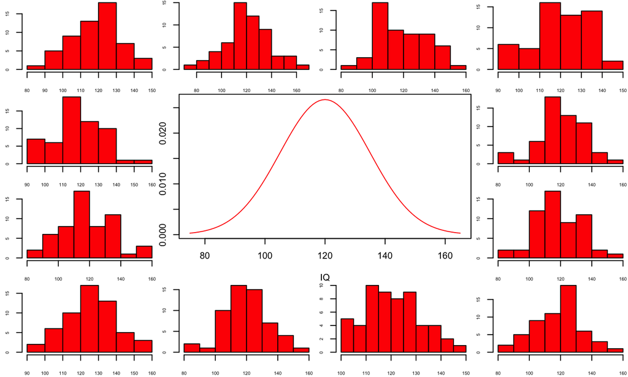

```r
layout(matrix(c(2:6,1,1,7:8,1,1,9:13), 4, 4))

n  = 56    # Sample size
df = n - 1 # Degrees of freedom

mu    = 120
sigma = 15

IQ = seq(mu-45, mu+45, 1)

par(mar=c(4,2,0,0))
plot(IQ, dnorm(IQ, mean = mu, sd = sigma), type='l', col="red")

n.samples = 12

for(i in 1:n.samples) {

  par(mar=c(2,2,0,0))
  hist(rnorm(n, mu, sigma), main="", cex.axis=.5, col="red")

}
```

## T-statistic

\[T_{n-1} = \frac{\bar{x}-\mu}{SE_x} = \frac{\bar{x}-\mu}{s_x / \sqrt{n}}\]

So the t-statistic represents the deviation of the sample mean \(\bar{x}\) from the population mean \(\mu\), considering the sample size, expressed as the degrees of freedom \(df = n - 1\)

## A samples

Let's take one sample from from our normal populatiion and calculate the t-value.

```r
x = rnorm(n, mu, sigma); x
```

```
##  [1] 114.47046 112.40285 111.36988 127.63612 112.65267 124.36971 117.11047
##  [8] 110.11353 121.38715 136.01337 120.41000 128.93502 104.82450 132.69035
## [15]  86.96867 106.53538 143.18553 129.21681 103.02637  95.53415 114.97534
## [22] 128.12247 118.28598 135.12857 126.81497  88.26230 124.05286 113.80356
## [29] 123.41687 104.11400 114.90884 141.05133  84.73933 123.47025 115.46142
## [36] 115.43624 132.18421 128.89112 129.27007 131.61467 137.74289 122.48756
## [43]  94.89572  99.25955 138.58232 150.53432 128.00215 118.10350 120.24324
## [50] 111.19961 124.75425 150.62285 113.13644 124.73999 115.78468 124.24503
```

```r
mean(x)
```

```
## [1] 119.7713
```

```r
t = (mean(x) - mu) / (sd(x) / sqrt(n)); t
```

```
## [1] -0.1174114
```

## More samples

let's take more samples and calculate the t-value every time.

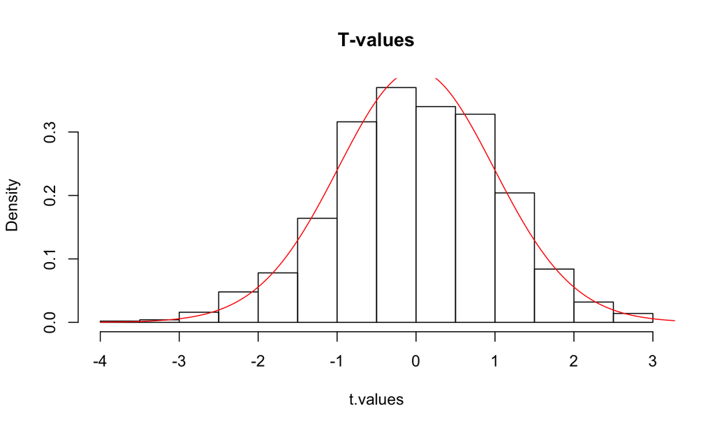

```r
n.samples = 1000

t.values = vector()

for(i in 1:n.samples) {

  x = rnorm(n, mu, sigma)

  t.values[i] = (mean(x) - mu) / (sd(x) / sqrt(n))

}

hist(t.values, freq = F, main="T-values")
T = seq(-4, 4, .01)
lines(T, dt(T,df), col = "red")
```

## T-distribution

So if the population is normaly distributed (assumption of normality) the t-distribution represents the deviation of sample means from the population mean (\(\mu\)), given a certain sample size (\(df = n - 1\)).

The t-distibution therefore is different for different sample sizes and converges to a standard normal distribution if sample size is large enough.

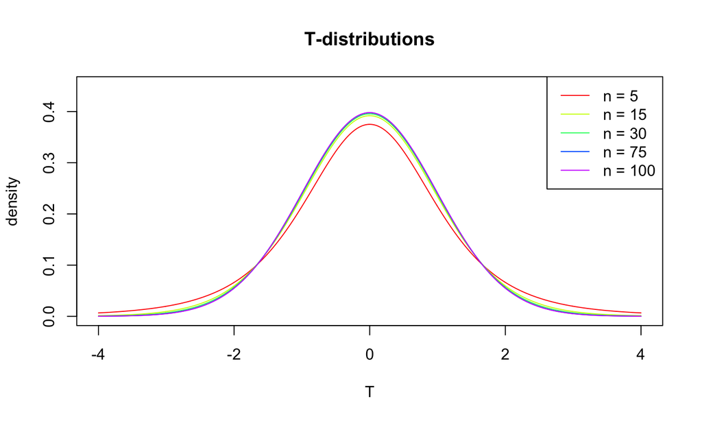

```r
multiple.n  = c(5, 15, 30, 75, 100)
multiple.df = multiple.n - 1
col         = rainbow(length(multiple.df))

plot(T,  dt(T, multiple.df[1]), type = "l",
     xlim = c(-4,4), ylim = c(0,.45),
     xlab = "T", ylab="density",
     col = col[1], main="T-distributions" )

for(i in 2:length(multiple.df)) {

  lines(T, dt(T, multiple.df[i]), type="l", col=col[i])
  }
legend("topright", legend = paste("n =",multiple.n), lty=1, col = col)
```

## One-sample t-test

## Compare sample mean

We use the one-sample t-test to compare the sample mean \(\bar{x}\) to the population mean \(\mu\).

```r
mu = 120
n  = length(IQ.van.je.buur)
x  = IQ.van.je.buur

mean(x)
```

```
## [1] 121.1266
```

Does this mean differ significantly from the population mean \(\mu = 120\)?

## Hypothesis

### Null hypothesis

- \(H_0: \bar{x} = \mu\)

### Alternative hypothesis

- \(H_0: \bar{x} \neq \mu\)
- \(H_0: \bar{x} > \mu\)
- \(H_0: \bar{x} < \mu\)

## T-statistic

\[T_{n-1} = \frac{\bar{x}-\mu}{SE_x} = \frac{\bar{x}-\mu}{s_x / \sqrt{n}}\]

So the t-statistic represents the deviation of the sample mean \(\bar{x}\) from the population mean \(\mu\), considering the sample size, expressed as the degrees of freedom \(df = n - 1\)

```r
t = (mean(x) - mu) / (sd(x) / sqrt(n)); t
```

```
## [1] 0.9485499
```

## Type I error

To determine if this t-value significantly differs from the population mean we have to specify an type I error that we are willing to make.

- Type I error / \(\alpha\) = .05

## *P*-value one sided

Finally we have to calculate our *p*-value

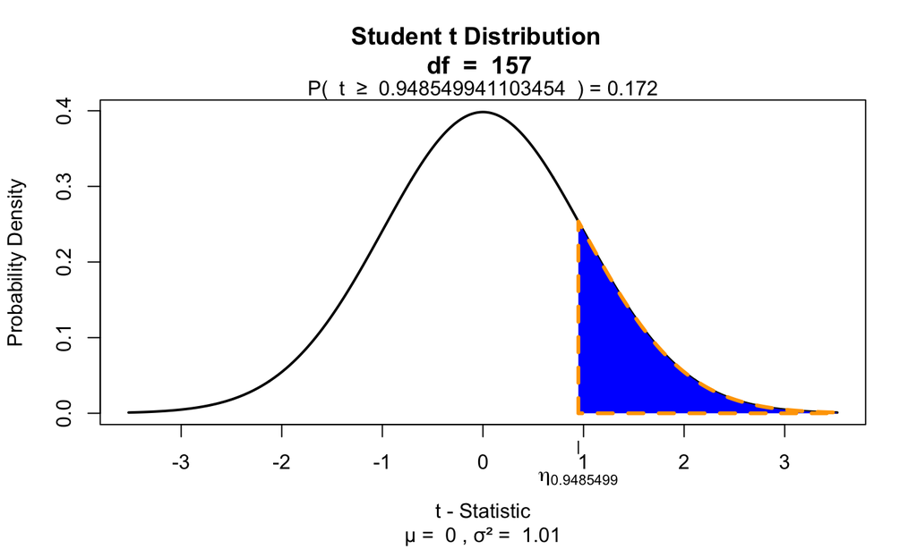

```r
df = n - 1

if(!"visualize" %in% installed.packages()) {
install.packages("visualize") }
library("visualize")

visualize.t(t, df, "upper")
```

## *P*-value two sided

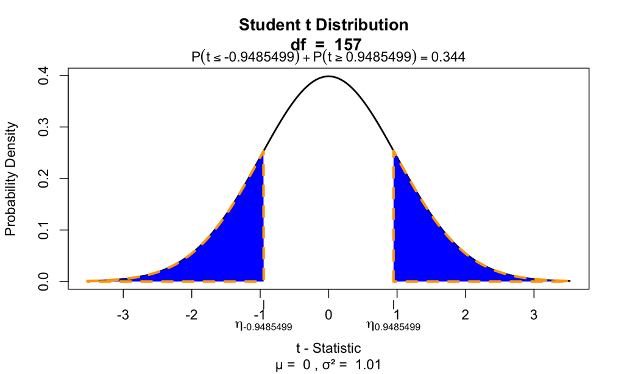

```r
visualize.t(c(-t, t), df, section = "tails")
```

## Effect-size

\[r = \sqrt{\frac{t^2}{t^2 + \text{df}}}\]

```r
r = sqrt(t^2/(t^2 + df))

r
```

```
## [1] 0.07548653
```

## END

[@shklinkenberg](https://twitter.com/shklinkenberg)